# Tugas Praktikum 1

Angga Fathan Rofiqy

29 January, 2024

> - **Code/Syntax :** [File.rmd](https://github.com/Zen-Rofiqy/STA1312-PSB/blob/main/Project/Tugas%20Prak%201%20Pert%201/G1401211006_Angga-Fathan-Rofiqy_Tugas-Praktikum-1.Rmd)

# No 1

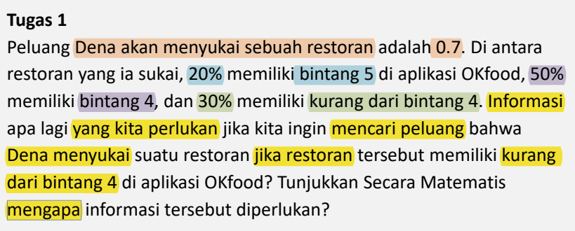

> **Misalkan**
> - `D` : Dena menyukai sebuah restoran
> - `B5` : Restoran rating bintang 5 di OKfood
> - `B4` : Restoran rating bintang 4 di OKfood
> - `Bk` : Restoran rating bintang kurang dari 4 di OKfood

> **Diketahui**
> - $P(D)=0.7$
> - $P(B5|D)=0.2$
> - $P(B4|D)=0.5$
> - $P(Bk|D)=0.3$

> **Ditanya:** $P(D|Bk)$ ?

## Penyelesaian

Menggunakan **rumus bayes,**

$P(B_j|A) = \frac{P(A|B_j) \times P(B_j)} {P(A)}$, dimana $P(A)=\sum^k_{i=1} P(A|B_i) \times P(B_i)$

Maka,

$P(D|Bk) = \frac{P(Bk|D) \times P(D)} {P(Bk)} = \frac{0.3 \times 0.7} {P(Bk)}$

Dimana, $\begin{equation}\begin{aligned} P(Bk) &= P(Bk|D) \times P(D) \text{ } + \text{ } P(Bk|D^c) \times P(D^c) \\ &= (0.3 \times 0.7) \text{ } + \text{ } P(Bk|D^c) \times 0.3 \end{aligned}\end{equation}$

Bisa dilihat bahwa informasi tambahan yang diperlukan apabila kita ingin mencari nilai $P(D|Bk)$ (Peluang Dena menyukai resto rating kurang dari 4) adalah $P(Bk|D^c)$ (Persentase resto rating kurang dari 4 yang tidak disukai Dena).

# No 2

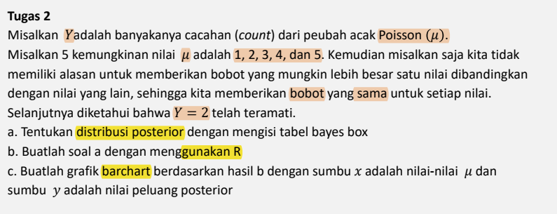

## Poin a

Likelihood sebaran Poisson dengan $Y=2$ :

$$P(Y=2|\mu)=\frac{e^{-\mu}\mu^2}{2!} \text{ , } \mu=1,2,3,4,5$$

Karena setiap nilai memiliki bobot yang sama, maka untuk setiap $\mu$ prior nya sama. Sehingga :

> Tabel bayes box

| $\mu$ | Prior | Likelihood | Prior $\times$ Likelihood | Posterior |
| --- | --- | --- | --- | --- |
| 1 | 1/5 | 0.1839 | 0.0368 | 0.2023 |
| 2 | 1/5 | 0.2707 | 0.0541 | 0.2976 |
| 3 | 1/5 | 0.2240 | 0.0448 | 0.2464 |
| 4 | 1/5 | 0.1465 | 0.0293 | 0.1611 |
| 5 | 1/5 | 0.0842 | 0.0168 | 0.0926 |
| Total |  |  | 0.1819 |  |

## Poin b

```r
# Nilai 𝜇 yang mungkin
mu <- c(1,2,3,4,5)
k <- 2 # Y=2
w <- 0 # Bobot nya sama

# Sebaran Poisson
pois.llh <- function(k, mu) return(dpois(k, mu))

post.dist <- function(k, mu, w){
  # Prior untuk setiap nilai 𝜇
  pri <- ifelse(w == 0, rep(1/length(mu), length(mu)), w)

  # Menghitung likelihood untuk Y=2 untuk setiap nilai 𝜇
  llh <- sapply(mu, pois.llh, k=k)

  # Menghitung Prior x likelihood
  pri.llh <- llh * pri

  # Menghitung Posterior
  post <- pri.llh / sum(pri.llh)

  data.frame( mu, pri, llh, pri.llh, post ) %>% return()
}

bayes.box <- post.dist(k, mu, w)
colnames(bayes.box) <- c("mu", "Prior", "Likelihood", "Prior x Likelihood", "Posterior")
bayes.box %>% datatable %>%
  formatRound(c(3,4,5), digits = 4)
```

|  | mu | Prior | Likelihood | Prior x Likelihood | Posterior |
| --- | --- | --- | --- | --- | --- |
| 1 | 1 | 0.2 | 0.1839397205857212 | 0.03678794411714423 | 0.2022645793140662 |
| 2 | 2 | 0.2 | 0.2706705664732254 | 0.05413411329464508 | 0.2976359216273421 |
| 3 | 3 | 0.2 | 0.2240418076553877 | 0.04480836153107755 | 0.2463618071718311 |
| 4 | 4 | 0.2 | 0.1465251111098735 | 0.02930502222197469 | 0.1611225670193064 |
| 5 | 5 | 0.2 | 0.08422433748856835 | 0.01684486749771367 | 0.09261512486745424 |

## Poin c

```r
ggplot(bayes.box[,c(1,5)], aes(x=factor(mu), y=Posterior)) +
  geom_bar(stat="identity", col=NA,
           fill= ifelse(bayes.box[,c(1,5)]$mu == 2,  "#1380A1", "#dddddd")) +
  labs(x = "\nNilai µ", y = "Peluang Posterior",
       title = "\nSebaran Posterior untuk Y = 2\n") +
  theme1.1
```

[figure not shown]

# No 3

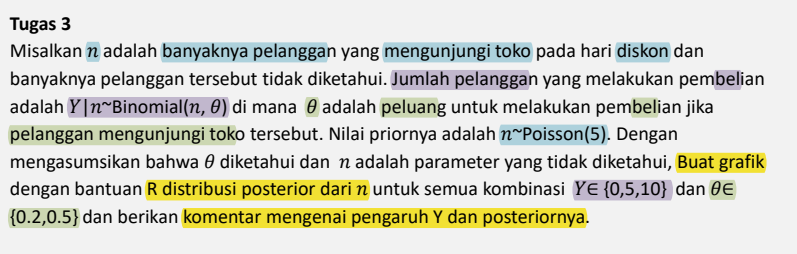

> **Diketahui**
> - `n` : banyaknya pelanggaan yang dateng ke toko pas hari diskon, $n \sim Poisson(5)$
> - `Y` : jumlah pelanggan yang beli, $Y|n \sim Binomial(n, \theta)$, dimana $Y \in \{0,5,10\}$
> - $\theta$ : peluang beli jika pelanggan dateng ke toko, $\theta \in \{0.2,0.5\}$

## Penyelesaian

Sebaran posterior dihitung untuk setiap kombinasi $Y$ dan $\theta$, yakni $\binom{4}{2}=6$, sehingga akan ada **6 grafik**.

```r
# Fungsi untuk menghitung distribusi posterior dari n
post.n <- function(y, theta, lamb.pois, n){
  # Menghitung prior Poisson
  pri <- dpois(n, lamb.pois)

  # Menghitung lilelihood Binomial P(Y|n, theta)
  llh <- dbinom(y, n, theta)

  # Menghitung posterior tidak ternomalisasi
  pri.llh <- pri * llh

  # Posterior
  post <- pri.llh / sum(pri.llh)
  return(post)
}

# Nilai-nilai yang mungkin untuk n
n.val <- 0:30

# Kombinasi nilai Y dan theta yang diberikan
Y.val <- c(0, 5, 10)
theta.val <- c(0.2, 0.5)

# Menghitung dan memplot distribusi posterior untuk semua kombinasi Y dan theta
post.plot <- function(Y.val, theta.val, n.val, lamb.pois){
  plot.list <- list()
  for(y in Y.val){
    for(theta in theta.val){
      post <- post.n(y, theta, lamb.pois, n.val)
      df <- data.frame(n=n.val, post=post)

      #Chart
      bar.max <- which(df$post == max(df$post))
      chart <- ggplot(df, aes(x=n, y=post)) +
        geom_bar(stat="identity", col=NA,
                 fill= ifelse(df$n %in% (bar.max-1),  "#1380A1", "#dddddd")) +
        labs(x = "\nn", y = "\nPeluang Posterior",
             title = paste0("\nSebaran Posterior n (Y=",y, ", \u03b8=", theta, ")")) +
        theme1.1
      plot.list[[paste0("Y=", y, "\u03b8=", theta)]] <- chart
    }
  }
  return(plot.list)
}

# Asumsikan lambda untuk distribusi Poisson adalah 5
lamb.pois <- 5

# Plot/Chart
chart <- post.plot(Y.val, theta.val, n.val, lamb.pois)
do.call("grid.arrange", c(chart, ncol=2))
```

[figure not shown]

Sehingga dapat disimpulkan bahwa banyaknya pelanggan yang membeli ($Y$) dan peluang untuk membeli jika pelanggan dateng ke toko ($\theta$) memberikan **informasi penting** terkait banyaknya pelanggan yang dateng ke toko pada hari diskon yang tercermin dalam sebaran posterior dari $n$.